# R Part 3: Basic Data Tidying

### Facets

Sometimes when you have a lot of data it can be useful to facet your plots. This is really easy! As you can see below. The different options for facets can be seen [here](https://www.datacamp.com/community/tutorials/facets-ggplot-r)

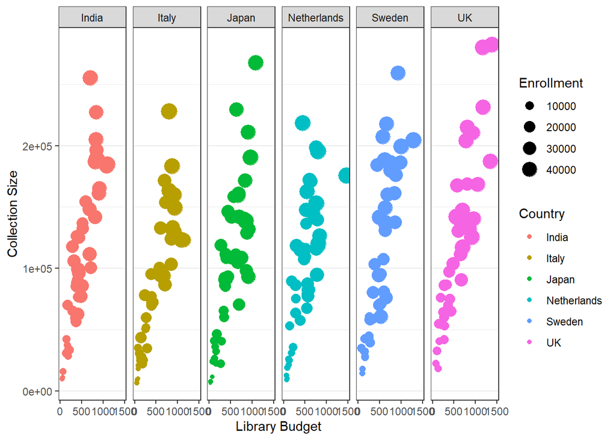

```r
ggplot(scatter,aes(x=Lib_Budget,y=Collection_Size))+
  geom_point(aes(colour=Country,size=Enrollment))+
  xlab("Library Budget")+
  ylab("Collection Size")+
  guides(colour=guide_legend(title="Country"),size=guide_legend(title="Enrollment"))+
  theme_bw()+
  theme(panel.grid.major.x = element_blank(),
        panel.grid.minor.x = element_blank())+
  facet_grid(~Country)
```

You can see that the facet made our x-axis labels difficult to see. Luckily this is one of the many elements we can fix in `theme()`

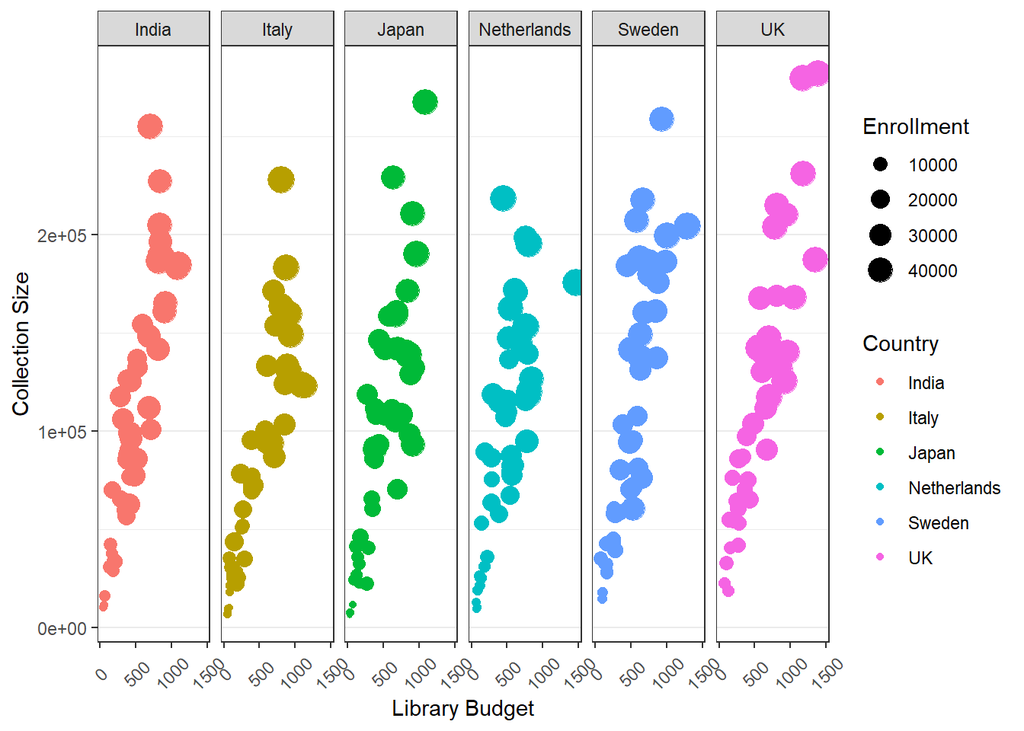

```r
ggplot(scatter,aes(x=Lib_Budget,y=Collection_Size))+
  geom_point(aes(colour=Country,size=Enrollment))+
  xlab("Library Budget")+
  ylab("Collection Size")+
  guides(colour=guide_legend(title="Country"),size=guide_legend(title="Enrollment"))+
  theme_bw()+
  theme(panel.grid.major.x = element_blank(),
        panel.grid.minor.x = element_blank(),
        axis.text.x = element_text(angle=45,vjust=0.5))+
  facet_grid(~Country)
```

### Changing Factor Levels

Remember up above with our bar plot we saw that the categories for the sleep dataset weren’t in the right order. We are going to reset the [factor levels](http://www.cookbook-r.com/Manipulating_data/Changing_the_order_of_levels_of_a_factor/) and then it should plot properly.

We’ll start with a basic plot of the old factor levels

```r
bar_ofl=ggplot(bar, aes(x=time,y=minutes,fill=year))+geom_bar(position="dodge",stat="identity")
```

Now lets reset the factor levels, then do the same plot again, and then compare the two

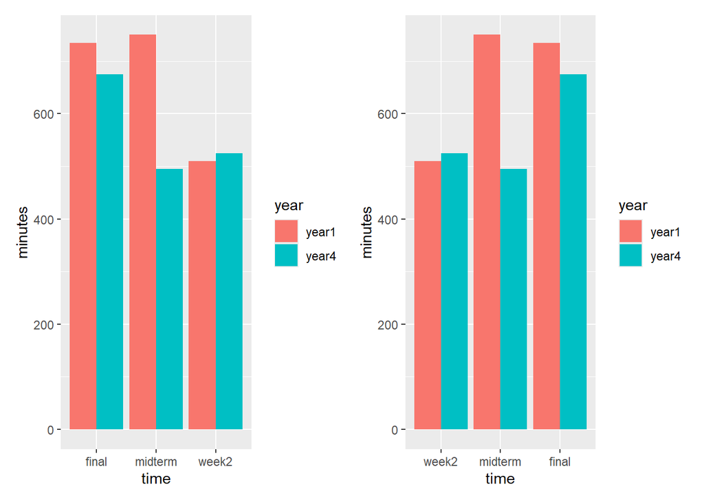

```r
bar$time <- factor(bar$time,levels = c("week2","midterm","final"))
bar_rfl=ggplot(bar, aes(x=time,y=minutes,fill=year))+geom_bar(position="dodge",stat="identity")
(bar_ofl|bar_rfl)
```

## Trouble shooting

- check the order of your layers
- check the class of the columns you are trying to use using `class()`
- check the factor levels with `levels()`
- to check how many of each category you have use `table(df$col)`

## Other Fun Examples

R also allows you to make animated vizualizations. For example we can look at the number of library visitors over a period of time, using synthetic data created by Melissa and Chantal for the Power BI session.

This was another opportunity for me to explore whether AI could code. I had tried a few years ago and it wasn’t perfect, so I tried with this application. The code ChatGPT gave me looked ok, but didn’t actually produce the image, I still had to troubleshoot, and it was not an issue I would have been able to fix quickly if I was a beginner.

[figure not shown]

```r
data=read.csv("data/synthetic_gatecounts.csv")%>%
  dplyr::select(name,date,visitors)%>%
  mutate(Timestamp=ymd_hm(date))%>% #make sure the time is interpreted in the correct format
  mutate(Date=date(Timestamp))%>% #extract the date
  dplyr::select(name,Date,visitors)

# Calculate cumulative visitors
data_cumulative <- data %>%
  arrange(name, Date) %>%
  group_by(name) %>%
  mutate(cumulative_visitors = cumsum(visitors)) %>%
  ungroup()

# Create animated bar plot
plot <- ggplot(data_cumulative, aes(x = reorder(name, -cumulative_visitors),
                                    y = cumulative_visitors,
                                    fill = name)) +
  geom_col(show.legend = FALSE) +
  labs(title = 'Cumulative Visitors by Place',
       subtitle = 'Date: {frame_time}',
       x = 'Name',
       y = 'Cumulative Visitors') +
  scale_y_continuous(labels = scales::comma) +
  transition_time(Date) +
  ease_aes('linear') +
  theme_minimal(base_size = 16)

# Animate
animate(plot, nframes = 100, fps = 10, width = 800, height = 600)
```